# **SCLC RNA-seq data analyzing pipeline**

Natalia Kropivnitskaya

18.03.2026

This R script implements a complete pipeline for processing and normalizing RNA-seq count data of Small lung-cell cancer (**SCLC**). The workflow includes gene filtering, duplicate resolution, metadata merging, expression filtering, TMM normalization, batch effect correction, and Principal Component Analysis (PCA) for quality control.

## **Setup and data loading**

Install necessary packages if it is required.

Set the working directory (preserved from original script).

```r
setwd("D:/final")
data_path <- "./data/"
outpath <- "./output/"
```

### Read in SCLC expression data and process it

```r
# Read SCLC data
CDX_data <- read.csv(paste0(data_path,"FinalCDXDataTable.csv"), strings = FALSE)


rownames(CDX_data) <- make.unique(CDX_data$gene_name)
CDX_data <- CDX_data[,-c(1, 2, 3)]
```

```r
head(CDX_data[1:6, 1:6])
```

|  | CDX01 | CDX01.1 | CDX01.2 | CDX02 | CDX02.1 | CDX02.2 |
| --- | --- | --- | --- | --- | --- | --- |
| TSPAN6 | 1222 | 1066 | 1223 | 1060 | 1628 | 1187 |
| TNMD | 1 | 2 | 0 | 0 | 0 | 0 |
| DPM1 | 1473 | 1219 | 1644 | 2087 | 2457 | 2027 |
| SCYL3 | 1015 | 743 | 939 | 323 | 526 | 520 |
| C1orf112 | 1176 | 967 | 1444 | 718 | 1159 | 918 |
| FGR | 3 | 0 | 3 | 11 | 9 | 12 |

This matrix contains the primary data for the analysis:

- **Rows**: genes.
- **Columns**: samples.
- **Values**: the raw read counts (the number of sequencing reads mapped to each gene in each sample). These counts must be normalized before comparison.

### Read in metadata and process it

This step loads the descriptive and categorical information (metadata) for all samples. This information is essential for defining the experimental design, including:

- **Biological groups**:
1. The tumor *subtypes* (clusters) for SCLC: samples: ASCL1, ATOH1, NEUROD1, POU2F3.
2. The tumor *stage* for SCLC samples: Early or Progression.
- **Batch factors**: Represents the *replicate identity* for each patient. It is used for batch effect correction to isolate true disease progression signals from patient-specific variance.

```r
# Load patient_ids metadata
CDX_metadata <- read.csv(paste0(data_path,"CDX_paper_batch_info.csv"), strings = FALSE)

# Load subtypes metadata
subtypes_metadata <- read.csv(paste0(data_path, "sclc_subtypes.csv"), stringsAsFactors = FALSE)

CDX_annotated <- CDX_metadata %>%
  left_join(subtypes_metadata, by = "sampleID") %>%
  mutate(
    stage = ifelse(grepl("P$", CDX), "Progression", "Early"),
    patient_id = gsub("P", "", CDX)
  )

# 74 early, 46 progression, 3 POU2F3, 12 NEUROD1, 15 ATOH1, 90 ASCL1
```

We leave only those patients for whom there are paired data on stages (Early and Progression).

```r
paired_patients <- CDX_annotated %>%
  group_by(patient_id) %>%
  summarise(
    has_normal = any(!grepl("P", CDX)),
    has_progression = any(grepl("P", CDX))
  ) %>%
  filter(has_normal & has_progression) %>%
  pull(patient_id)

progression_annotated <- CDX_annotated %>%
  filter(patient_id %in% paired_patients) %>%
  mutate(stage = ifelse(grepl("P$", CDX), "Progression", "Early"))
# 19 early, 22 progression, 26 ASCL1, 9 ATOH1, 6 NEUROD1
```

```r
head(progression_annotated[1:6, 1:6])
```

|  | CDX | sampleID | Batch | subtype | stage | patient_id |
| --- | --- | --- | --- | --- | --- | --- |
| 1 | CDX03 | CDX03 | CD7 | ASCL1 | Early | CDX03 |
| 2 | CDX03 | CDX03.1 | CD7 | ASCL1 | Early | CDX03 |
| 3 | CDX03 | CDX03.2 | CD7 | ASCL1 | Early | CDX03 |
| 4 | CDX03P | CDX03P | CD7 | ASCL1 | Progression | CDX03 |
| 5 | CDX03P | CDX03P.1 | CD7 | ASCL1 | Progression | CDX03 |
| 6 | CDX08 | CDX08 | CD7 | NEUROD1 | Early | CDX08 |

We leave the RNA expression data of the corresponding samples in the CDX_data dataset.

```r
CDX_data <- CDX_data[, progression_annotated$sampleID]
```

```r
head(CDX_data[1:6, 1:6])
```

|  | CDX03 | CDX03.1 | CDX03.2 | CDX03P | CDX03P.1 | CDX08 |
| --- | --- | --- | --- | --- | --- | --- |
| TSPAN6 | 3446 | 2164 | 2375 | 2179 | 1367 | 1269 |
| TNMD | 0 | 0 | 0 | 0 | 0 | 0 |
| DPM1 | 2424 | 1623 | 2453 | 2097 | 1727 | 1084 |
| SCYL3 | 615 | 491 | 547 | 500 | 533 | 324 |
| C1orf112 | 1312 | 1060 | 1057 | 1085 | 1343 | 915 |
| FGR | 26 | 27 | 17 | 4 | 17 | 18 |

## **Filtering, creating DGEList and removing batch-effect**

### Initializing DGEList and Filtering

- `combined_group`: a factor created by merging subtype and stage (e.g., “ASCL1_Early”). This ensures the filtering process recognizes the unique biological replicates within each sub-condition.
- `DGEList`: the core edgeR data object. It stores the raw count matrix, sample metadata, and the grouping factor used for downstream statistical calculations.
- `filterByExpr(...)`: an automated method to remove lowly expressed genes. It keeps genes that have a minimum count in enough samples to allow for reliable statistical inference, based on the combined_group.

```r
# Creating a combined group for filtering and design
combined_group <- factor(paste(progression_annotated$subtype, progression_annotated$stage, sep = "_"))

# Initializing the DGEList object
dge <- DGEList(
  counts = CDX_data,
  samples = progression_annotated,
  group = combined_group
)

# Gene filtering to remove low-count noise
keep <- filterByExpr(dge)
dge <- dge[keep, , keep.lib.sizes = FALSE]
```

#### Calculate normalized log-CPM before batch correction

- `calcNormFactors(dge)`: calculates TMM (Trimmed Mean of M-values) normalization factors to correct for composition bias between libraries.
- `cpm(...)`: converts raw counts to Counts Per Million (CPM), normalizing for differences in sequencing depth (library size).
- `log = TRUE`: applies a $\log_2(x + \text{prior.count})$ transformation. This stabilizes the variance across the expression range, making the data suitable for linear modeling methods like `removeBatchEffect`.
- `nonbatched`: represents the fully normalized data before the patient-specific “batch” effect is removed.

```r
# EdgeR normalizarion
dge <- calcNormFactors(dge)
nonbatched <- cpm(dge, log = TRUE)
```

### Batch correction

- `design`: a model matrix that tells the algorithm which biological differences (subtypes and stages) should be preserved. By including combined_group, we ensure that the variation we care about is not accidentally removed.
- `batch`: a factor representing the patient_id. In this context, the “batch” is the individual patient background.
- `removeBatchEffect(...)`: a `limma` function that fits a linear model to estimate the effect of the patient identity on every gene and subtracts it.
- `debatched`: the final expression matrix where patient-specific variance has been mathematically removed, leaving primarily the biological variation related to SCLC progression.

```r
# Defining the biological design to be protected
design <- model.matrix(~0 + combined_group)

# Defining the patient-specific batch factor
batch <- factor(progression_annotated$patient_id)

# Batch correction to isolate progression signals
debatched <- removeBatchEffect(nonbatched, batch = batch, design = design)
```

```
## Coefficients not estimable: batch3 batch5
```

## **Visualization (PCA)**

#### Creating a function for PCA plotting

This function standardizes the visualization of PCA results. It maps color to the **SCLC subtype** and shape to the **Disease stage**. It also automatically calculates the explained variance for the axes.

```r
# Define palettes for consistency
subtype_palette <- c(
  "ASCL1"    = "#E41A1C", # Red
  "NEUROD1"  = "#377EB8", # Blue
  "ATOH1"    = "#4DAF4A"  # Green
  #"POU2F3"   = "#FFFF00" # Violet
)

stage_shapes <- c(
  "Early"       = 16, # Empty circle
  "Progression" = 15  # Empty square
)

plot_sclc_pca <- function(pca_res, meta_data, title_suffix) {
  # Calculate variance explained
  pc_vars <- round(summary(pca_res)$importance[2, 1:2] * 100, 1)

  # Match expression data and metadata for correct PCA plotting
  sample_ids <- rownames(pca_res$x)
  matched_meta <- meta_data[match(sample_ids, meta_data$sampleID), ]

  # Prepare plotting data
  df <- data.frame(
    PC1 = pca_res$x[, 1],
    PC2 = pca_res$x[, 2],
    stage = matched_meta$stage,
    subtype = matched_meta$subtype,
    sampleID = sample_ids
  )

  # Create plot
  ggplot(df, aes(x = PC1, y = PC2, color = subtype, shape = stage)) +
    geom_point(size = 2, alpha = 0.8) +
    geom_text_repel(
      aes(label = sampleID),
      size = 2.5,
      show.legend = FALSE,
      max.overlaps = 20
    ) +
    scale_color_manual(values = subtype_palette) +
    scale_shape_manual(values = stage_shapes) +
    labs(
      title = paste("PCA of SCLC CDX models:", title_suffix),
      subtitle = "Color by subtype, Shape by stage",
      x = paste0("PC1 (", pc_vars[1], "%)"),
      y = paste0("PC2 (", pc_vars[2], "%)"),
      color = "Subtype",
      shape = "Disease stage"
    ) +
    theme_minimal() +
    theme(legend.box = "vertical")
}
```

### PCA plotting

Principal Component Analysis (PCA) is performed to visually assess the dataset’s overall variance structure and to confirm the effectiveness of the batch correction. PCA is run on the *transpose* of the expression matrix (samples as rows).

The `prcomp()` function calculates the principal components on both the uncorrected and corrected data

We now generate the two plots to assess the effectiveness of the batch correction. In the *After* plot, we expect to see samples from the same subtype clustering more tightly, regardless of their individual patient background.

**PCA before batch correction**

```r
pca_before <- prcomp(t(nonbatched), scale. = TRUE)
```

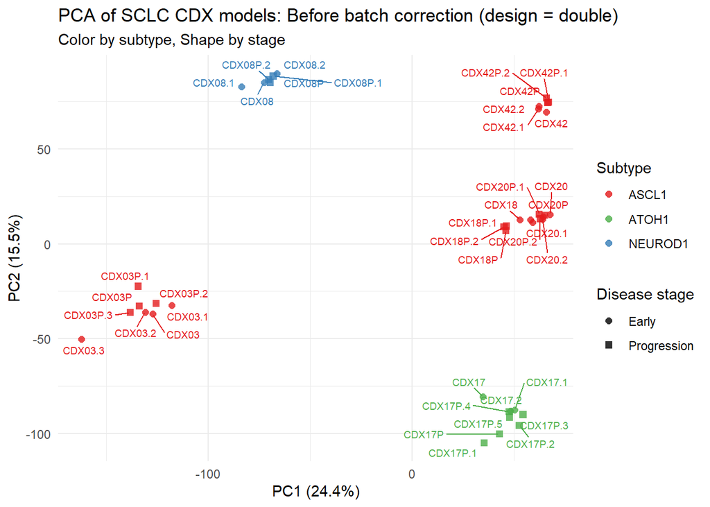

```r
# Plot before batch correction
plot_sclc_pca(pca_before, progression_annotated, "Before batch correction (design = double)")
```

**PCA after batch correction**

```r
pca_after <- prcomp(t(debatched), scale. = TRUE)
```

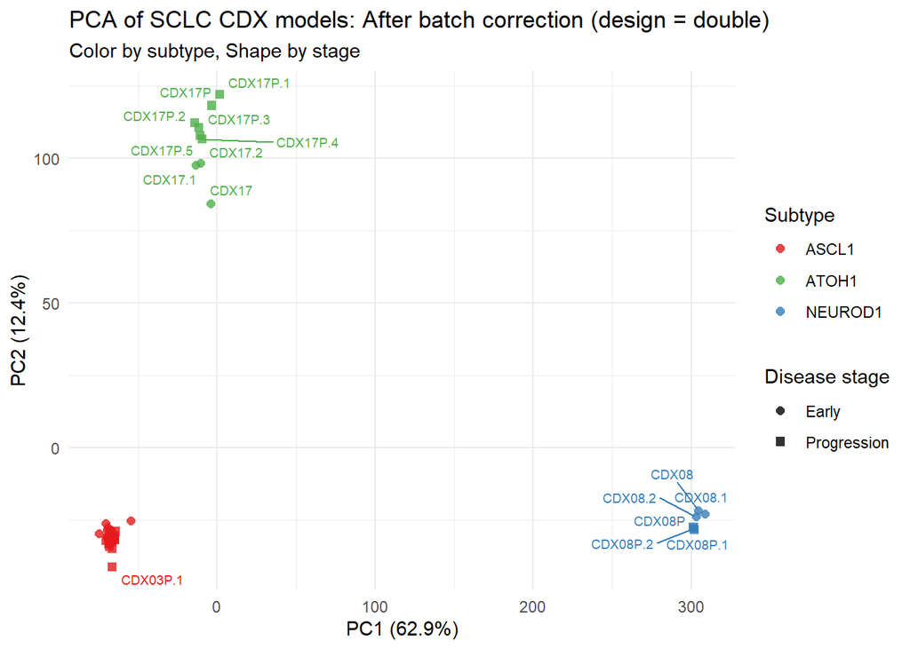

```r
# Plot after batch correction
plot_sclc_pca(pca_after, progression_annotated, "After batch correction (design = double)")
```

## **SCLC data postprocessing**

### Loading the necessary data

```r
# 1. Load ANOVA results: contains statistical significance (p-values, FDRs) for each cluster of motifs or motif (depends on what you run MARADONER on)
anova_data <- read_tsv(paste0(outpath, "double_41samples/sclc_double_debatched_41samples/tests/asymptotics_based/anova.tsv")) %>%
  rename(Motif = ...1)

# 2. Load Activity results: contains the calculated TF activity scores for each group of samples (also could be adjusted before running MARADONER)
activity_data <- read_tsv(paste0(outpath, "double_41samples/sclc_double_debatched_41samples/activities/activity.tsv")) %>%
  rename(Motif = ...1)

# 3. Load information about motif clusters
cluster_info <- read_tsv(paste0(data_path, "cluster_list.tsv"))

# 4. Load filtered SCLC data (after merging with gene_occupancy.tsv file and running MARADONER)
rna_data <- read_tsv(paste0(outpath, "double_41samples/sclc_double_debatched_41samples_filtered.tsv")) %>%
  column_to_rownames(var = "...1")
```

### Motif filtering and gene-level mapping

After processing the MARADONER outputs, we perform two critical steps: identifying the most significant transcription factor (TF) motifs and extracting the specific genes associated with those motifs for further visualization.

This section processes the results generated by the Maradoner pipeline using a **Double design approach**. This model incorporates both tumor progression stages and tumor subtypes into the design matrix. This integrated strategy allows us to identify robust regulatory motifs that maintain their significance while accounting for the two primary sources of biological variability in the cohort.

The analysis begins by importing the following key datasets:

- **ANOVA results**: statistical testing data identifying motifs that significantly vary when considering the interaction or additive effects of both stage and subtype.
- **Activity scores**: quantified motif activities across the 41-sample cohort, providing a high-resolution map of regulatory intensity.
- **Transcriptomic data**: RNA-seq expression levels processed through a comprehensive batch correction that preserves variance for both biological covariates.
- **Cluster mapping**: annotation data linking identified motifs to their respective gene clusters for targeted expression plotting.

To ensure we focus on the most reliable regulatory drivers, we apply a statistical threshold (`FDR < 0.05`) to the ANOVA results. These significant motifs are then merged with their activity scores and ranked by their False Discovery Rate (`FDR`). This approach prioritizes motifs that are not just artifacts of one specific condition, but are fundamental to the broader biological progression of the samples.

```r
# Keep only motifs with significant variation across groups
P_VALUE_THRESHOLD <- 0.05
final_significant <- anova_data %>%
  filter(FDR < P_VALUE_THRESHOLD) %>%
  inner_join(activity_data, by = "Motif") %>%
  arrange(`FDR`)

progression_annotated <- progression_annotated %>% arrange(stage) %>% arrange(subtype)
rna_data_ordered <- rna_data[, progression_annotated$sampleID]
```

### Creating a function for heatmap plotting

The plot_motif_heatmap function is a custom visualization tool designed to bridge the gap between regulatory motif analysis and gene expression data. It allows us to visualize the activity of a specific transcription factor motif by plotting the expression levels of its associated target genes across our samples.

```r
#' Plot Motif Heatmap
#' @param motif_name String name of the motif (e.g., "ASCL1" or "KAISO")
#' @param rna_matrix The expression matrix (e.g., debatched)
#' @param annot_data The sample metadata (e.g., CDX_annotated)
#' @param cluster_df The motif-to-gene mapping table (cluster_info)
#' @param plot_title Optional custom title
plot_motif_heatmap <- function(motif_name,
                               rna_matrix = rna_data,
                               annot_data = CDX_annotated,
                               cluster_df = cluster_info,
                               hier_clust = FALSE,
                               plot_title = NULL) {

  # 1. Extract gene symbols belonging to the motif cluster
  cluster_row <- cluster_df %>%
    filter(grepl(motif_name, Clustered_Motifs, fixed = TRUE))

  if (nrow(cluster_row) == 0) {
    stop(paste("Error: Motif", motif_name, "not found in cluster_info."))
  }

  # Parse genes and find intersection with your expression data
  genes_list <- unlist(strsplit(cluster_row$Clustered_Motifs_Gene_Symbols, "; "))
  genes_present <- intersect(genes_list, rownames(rna_matrix))

  if (length(genes_present) == 0) {
    stop(paste("Error: No genes for motif", motif_name, "found in expression matrix."))
  }

  # Determine if we are dealing with a single-gene motif
  is_single_gene <- length(genes_present) == 1

  # 2. Synchronize samples and prepare the plot matrix
  common_samples <- intersect(annot_data$sampleID, colnames(rna_matrix))
  current_matrix <- rna_matrix[genes_present, common_samples]

  # If single gene, force back into matrix format (pheatmap requirement)
  if (is_single_gene) {
    current_matrix <- matrix(as.numeric(unlist(current_matrix)), nrow = 1)
    colnames(current_matrix) <- common_samples
    rownames(current_matrix) <- genes_present
  } else {
    current_matrix <- as.matrix(current_matrix)
  }

  # 3. Prepare metadata annotation
  # Ensure rownames of annotation match colnames of matrix for pheatmap to render colors
  current_annot <- annot_data %>%
    filter(sampleID %in% common_samples) %>%
    column_to_rownames("sampleID") %>%
    select(subtype, stage)

  # 4. Define color palettes for consistency
  anno_colors <- list(
    subtype = c("ASCL1" = "#E41A1C", "NEUROD1" = "#377EB8",
                #"POU2F3" = "#FFFF00",
    "ATOH1" = "#4DAF4A"),
    stage = c("Early" = "#66C2A5", "Progression" = "#FC8D62")
  )

  # 5. Generate heatmap
  pheatmap(
    current_matrix,
    annotation_col = current_annot,
    annotation_colors = anno_colors,
    main = ifelse(is.null(plot_title), paste("Motif Activity:", motif_name), plot_title),
    color = colorRampPalette(c("navy", "white", "firebrick3"))(50),

    # Adaptive scaling: disable row clustering and scaling for single-gene motifs
    scale = if(is_single_gene) "none" else "row",
    cluster_rows = if(is_single_gene) FALSE else TRUE,

    cluster_cols = hier_clust,
    show_colnames = TRUE,
    border_color = NA,
    fontsize_row = 10,
    fontsize_col = 10
  )
}
```

Let’s see how the heatmap look like for KAISO cluster of motifs

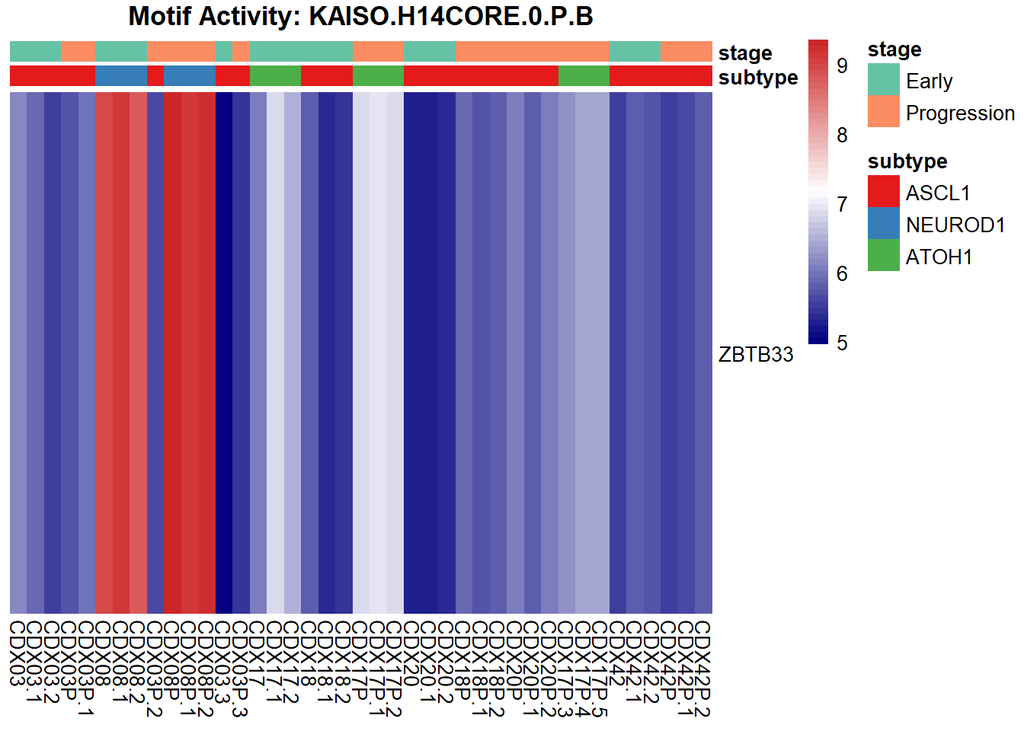

```r
plot_motif_heatmap('KAISO.H14CORE.0.P.B')
```

For KAISO and some other motif clusters, we have only 1 gene that present in our data. It is better to use boxplot to visualize statistical difference between groups.

[figure not shown]

```r
# Boxplot
gene_name <- "ZBTB33"
plot_df <- data.frame(
  Expression = as.numeric(debatched[gene_name, ]),
  Subtype = progression_annotated$subtype,
  Stage = progression_annotated$stage
)


ggplot(plot_df, aes(x = Subtype, y = Expression, fill = Subtype)) +
  geom_boxplot(outlier.shape = NA, alpha = 0.5) +
  geom_jitter(aes(shape = Stage), width = 0.2, size = 2.5, stroke = 1) +
  scale_fill_manual(values = c("ASCL1" = "#E41A1C", "NEUROD1" = "#377EB8",
                               "POU2F3" = "#7570B3", "ATOH1" = "#4DAF4A")) +

  labs(title = paste("Expression of", gene_name),
       subtitle = "Associated with KAISO motif",
       y = "Log2 CPM (debatched)",
       x = "Subtype") +
  theme_minimal() +
  theme(legend.position = "right")
```

### Contrasts between Progression and Early stages in each subtype

```r
# Creating a function for plotting contrasts
get_contrast_heatmap <- function(subtype_name, activity_mat, out_path, title) {

  # 1. Load contrast data
  file_path <- paste0(out_path, "double_41samples/results/", subtype_name, "/constrast.tsv")

  if (!file.exists(file_path)) {
    return(grid::textGrob(paste("File not found for", subtype_name)))
  }

  contrast_df <- read_tsv(file_path, show_col_types = FALSE) %>%
    rename(Motif = ...1)

  # 2. Define target columns in activity_data
  col_early <- paste0(subtype_name, "_Early")
  col_prog  <- paste0(subtype_name, "_Progression")

  # Check if columns exist
  if (!all(c(col_early, col_prog) %in% colnames(activity_mat))) {
    return(grid::textGrob(paste("Columns missing for", subtype_name)))
  }

  # 3. data preparation logic
  # select top-30 up-regulated
  top_up_motifs <- contrast_df %>%
    arrange(pval) %>%
    arrange(desc(z_stat)) %>%
    head(30) %>%
    pull(Motif)

  # Select top-30 down-regulated
  top_down_motifs <- contrast_df %>%
    arrange(pval) %>%
    arrange(z_stat) %>%
    head(30) %>%
    pull(Motif)

  # Combine candidate motifs
  candidate_motifs <- c(top_up_motifs, top_down_motifs)

  # 4. Extract data using the 'Motif' column
  activity_sub_df <- activity_mat %>%
    filter(Motif %in% candidate_motifs) %>%
    # Ensure the rows follow the specific order (top-up then top-down)
    slice(match(candidate_motifs, Motif)) %>%
    drop_na(Motif)

  if (nrow(activity_sub_df) == 0) {
    return(grid::textGrob(paste("No matching motifs for", subtype_name)))
  }

  # Prepare the numeric matrix for pheatmap
  plot_matrix <- activity_sub_df %>%
    column_to_rownames("Motif") %>%
    select(all_of(c(col_early, col_prog))) %>%
    as.matrix()

  # 5. Generate heatmap
  p <- pheatmap(plot_matrix,
                main = title,
                cluster_cols = FALSE,
                cluster_rows = FALSE,
                color = colorRampPalette(c("navy", "white", "firebrick3"))(50),
                fontsize_row = 4,
                fontsize_main = 25,
                fontsize_col = 8,
                angle_col = "45",
                silent = TRUE)

  return(grid.grabExpr(print(p)))
}
```

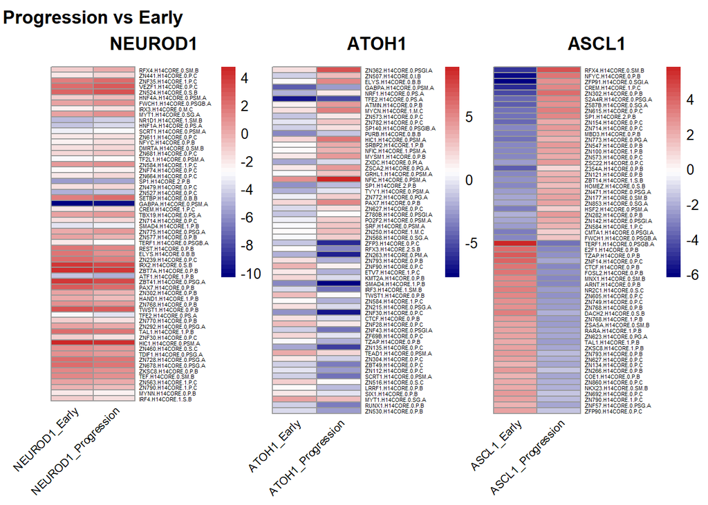

```r
# Creating a list of plots
plots <- list(
  get_contrast_heatmap("NEUROD1", activity_data, outpath, "Progression vs Early
                       NEUROD1"),
  get_contrast_heatmap("ATOH1",   activity_data, outpath, "
                       ATOH1"),
  get_contrast_heatmap("ASCL1",   activity_data, outpath, "
                       ASCL1")
)

# Rendering everything in one row (3 columns)
spacer <- grid::rectGrob(gp = grid::gpar(col = "white"))

grid.arrange(
  spacer, plots[[1]], plots[[2]], plots[[3]],
  ncol = 4,
  widths = c(0.2, 1, 1, 1)
)
```

## **Stage-based batch correction**

In this step, we perform batch correction using disease stage as the primary biological covariate. By setting the design matrix to account for stages, we preserve the variance associated with disease progression while removing patient-specific technical noise. This allows us to observe motif activity when the underlying biological signal is driven specifically by the progression stages.

```r
progression_group <- factor(paste(progression_annotated$stage))

dge <- DGEList(
  counts = CDX_data,
  samples = progression_annotated,
  group = progression_group
)

keep <- filterByExpr(dge)
dge <- dge[keep, , keep.lib.sizes = FALSE]

design <- model.matrix(~0 + progression_group)
batch <- factor(progression_annotated$patient_id)
debatched <- removeBatchEffect(nonbatched, batch = batch, design = design)
```

### PCA plotting

**PCA before batch correction**

```r
pca_before <- prcomp(t(nonbatched), scale. = TRUE)
```

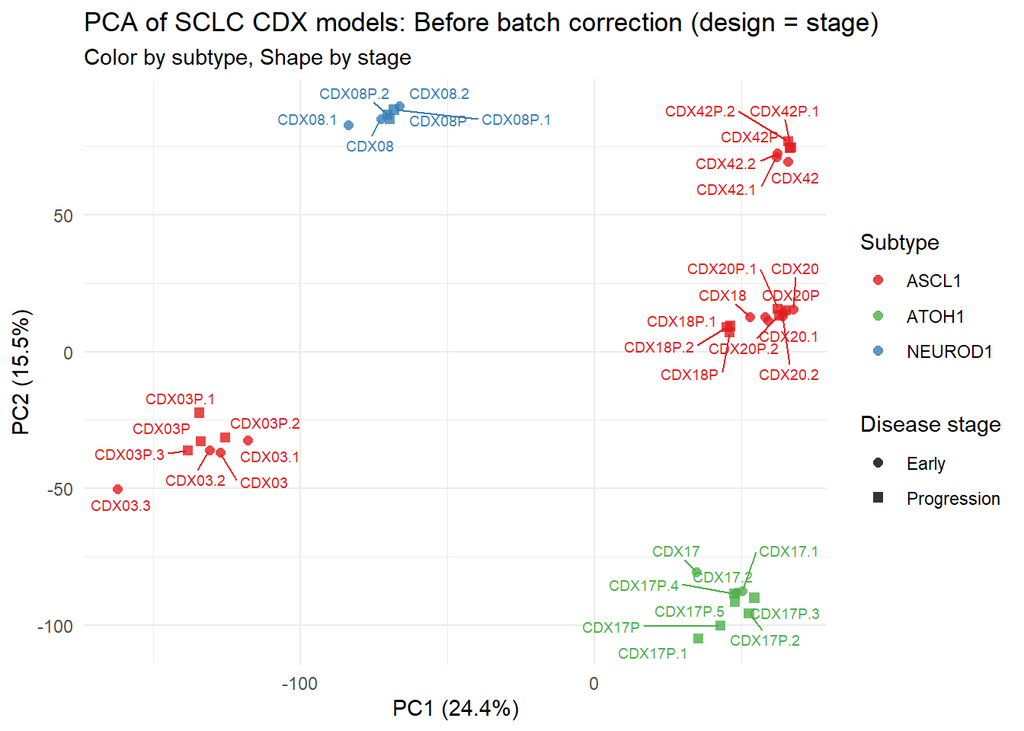

```r
# Plot before batch correction
plot_sclc_pca(pca_before, progression_annotated, "Before batch correction (design = stage)")
```

**PCA after batch correction**

```r
pca_after <- prcomp(t(debatched), scale. = TRUE)
```

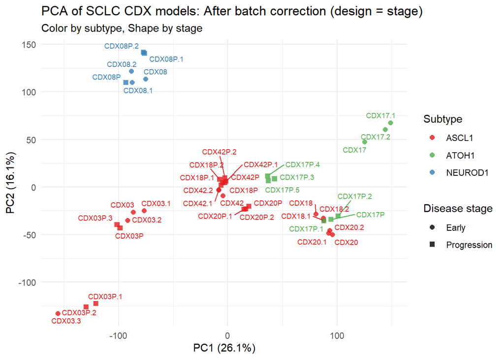

```r
# Plot after batch correction
plot_sclc_pca(pca_after, progression_annotated, "After batch correction (design = stage)")
```

### Stage-driven motif analysis

*After running maradoner (see file maradoner_pipeline.sh)*

This section processes the results generated by the Maradoner pipeline, specifically focusing on the analysis where the design is driven by tumor progression stages (neutralizing subtype-specific variance). The goal is to identify and visualize regulatory motifs that characterize the biological transition from early-stage to advanced-stage disease.

The analysis begins by importing several key datasets:

- **ANOVA results**: statistical testing data used to determine the significance of each motif relative to disease stage.
- **Activity scores**: quantified motif activities across the 41-sample cohort, reflecting the regulatory state of each stage.
- **Transcriptomic data**: debatched RNA-seq expression levels processed using the stage-based design matrix.
- **Cluster mapping**: annotation data linking specific motifs to their representative gene symbols to allow for downstream expression visualization.

To isolate the most biologically relevant signals, we apply a strict statistical threshold (`FDR < 0.05`) to the ANOVA results. The resulting significant motifs are merged with their respective activity scores and ranked by their False Discovery Rate (`FDR`). This ranking highlights the transcription factors most consistently associated with the clinical progression of the disease.

```r
anova_data_stage <- read_tsv(paste0(outpath, "stage_41samples/debatched_stage_41samples/tests/asymptotics_based/anova.tsv")) %>%
  rename(Motif = ...1)

activity_data_stage <- read_tsv(paste0(outpath, "stage_41samples/debatched_stage_41samples/activities/activity.tsv")) %>%
  rename(Motif = ...1)

cluster_info <- read_tsv(paste0(data_path, "cluster_list.tsv"))

rna_data_stage <- read_tsv(paste0(outpath, "stage_41samples/debatched_stage_41samples_filtered.tsv")) %>%
  column_to_rownames(var = "...1")

P_VALUE_THRESHOLD <- 0.05
final_significant_stage <- anova_data_stage %>%
  filter(FDR < P_VALUE_THRESHOLD) %>%
  inner_join(activity_data_stage, by = "Motif") %>%
  arrange(`FDR`)

progression_annotated <- progression_annotated %>% arrange(stage) %>% arrange(subtype)
rna_data_stage_ordered <- rna_data_stage[, progression_annotated$sampleID]
```

## **Subtype-based batch correction**

Next, we repeat the correction process, but substitute stages with molecular subtypes in our design matrix. This approach ensures that the variance defining specific subtypes is protected during batch effect removal. We use this to evaluate how motif activity profiles change when the biological variability is defined by subtype identity rather than clinical stage.

```r
subtype_group <- factor(paste(progression_annotated$subtype))

dge <- DGEList(
  counts = CDX_data,
  samples = progression_annotated,
  group = subtype_group
)

keep <- filterByExpr(dge)
dge <- dge[keep, , keep.lib.sizes = FALSE]

design <- model.matrix(~0 + subtype_group)
batch <- factor(progression_annotated$patient_id)
debatched <- removeBatchEffect(nonbatched, batch = batch, design = design)
```

```
## Coefficients not estimable: batch3 batch5
```

### PCA plotting

**PCA before batch correction**

```r
pca_before <- prcomp(t(nonbatched), scale. = TRUE)
```

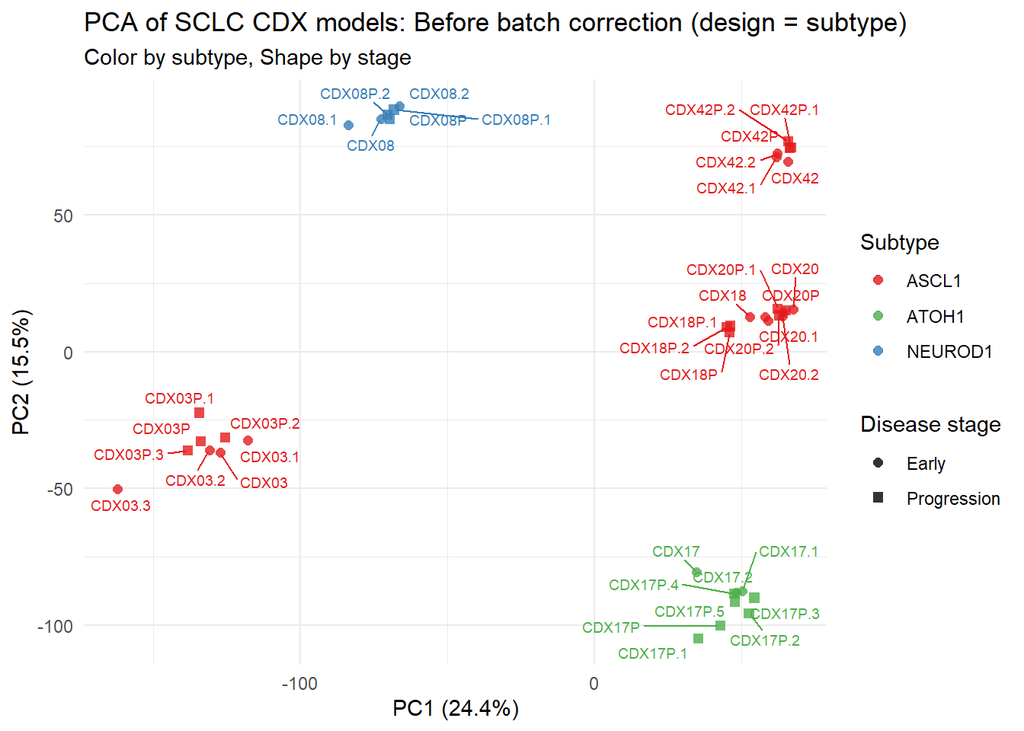

```r
# Plot before batch correction
plot_sclc_pca(pca_before, progression_annotated, "Before batch correction (design = subtype)")
```

**PCA after batch correction**

```r
pca_after <- prcomp(t(debatched), scale. = TRUE)
```

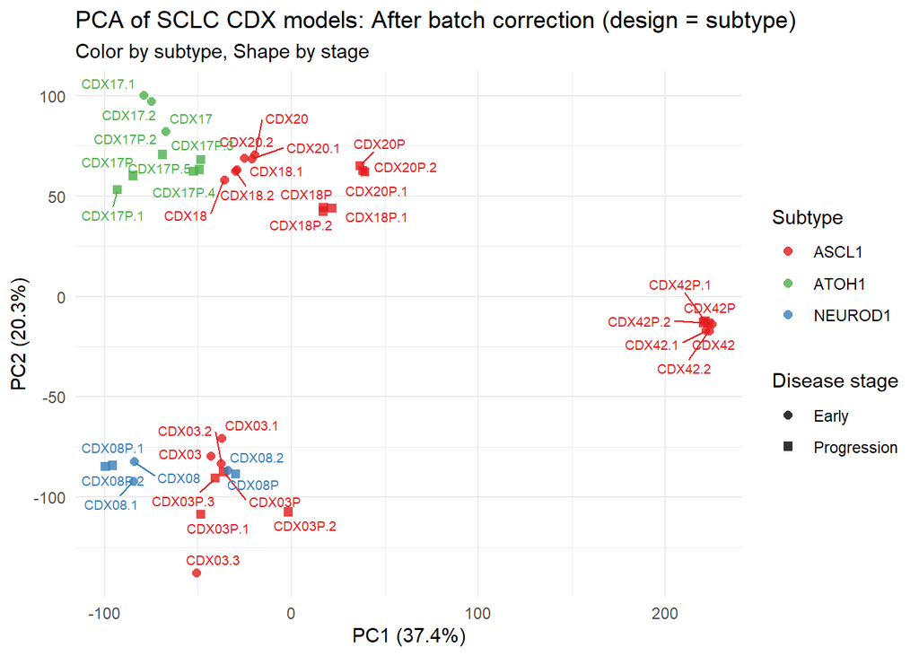

```r
# Plot after batch correction
plot_sclc_pca(pca_after, progression_annotated, "After batch correction (design = subtype)")
```

### Subtype-driven motif analysis

*After running maradoner (see file maradoner_pipeline.sh)*

This section processes the results generated by the Maradoner pipeline, specifically focusing on the analysis where the design is driven by tumor subtypes (excluding stage-based variance). The goal is to identify and visualize regulatory motifs that characterize the biological differences between SCLC subtypes.

The analysis begins by importing several key datasets:

- **ANOVA results**: statistical testing data used to determine the significance of each motif.
- **Activity scores**: quantified motif activities across the 41-sample cohort.
- **Transcriptomic data**: debatched RNA-seq expression levels corresponding to the subtype-based design.
- **Cluster mapping**: annotation data linking specific motifs to their representative gene symbols.

To isolate the most biologically relevant signals, we apply a statistical threshold (`FDR < 0.05`) to the ANOVA results. The resulting significant motifs are then merged with their activity scores and ranked by their false discovery rate (FDR).

```r
anova_data_subtype <- read_tsv(paste0(outpath, "subtype_41samples/debatched_subtype_41samples/tests/asymptotics_based/anova.tsv")) %>%
  rename(Motif = ...1)

activity_data_subtype <- read_tsv(paste0(outpath, "subtype_41samples/debatched_subtype_41samples/activities/activity.tsv")) %>%
  rename(Motif = ...1)

cluster_info <- read_tsv(paste0(data_path, "cluster_list.tsv"))

rna_data_subtype <- read_tsv(paste0(outpath, "subtype_41samples/debatched_subtype_41samples_filtered.tsv")) %>%
  column_to_rownames(var = "...1")

P_VALUE_THRESHOLD <- 0.05
final_significant_subtype <- anova_data_subtype %>%
  filter(FDR < P_VALUE_THRESHOLD) %>%
  inner_join(activity_data_subtype, by = "Motif") %>%
  arrange(`FDR`)

progression_annotated <- progression_annotated %>% arrange(stage) %>% arrange(stage)
rna_data_subtype_ordered <- rna_data_subtype[, progression_annotated$sampleID]
```

## **Comparison of motif activities**

Before visualizing the expression patterns, we provide a tabular overview of the top-ranked motifs identified in each experimental design. These tables summarize the statistical strength of each transcription factor’s activity based on the results from the Maradoner pipeline.

```r
head(final_significant, 15)
```

| Motif | stat | p-value | FDR | ASCL1_Early | ASCL1_Progression | ATOH1_Early | ATOH1_Progression | NEUROD1_Early | NEUROD1_Progression |
| --- | --- | --- | --- | --- | --- | --- | --- | --- | --- |
| E2F1.H14CORE.0.P.B | 3.500744 | 0.0004639618 | 0.0155315 | 3.82379527 | -3.0543225 | 0.2434952 | 1.9584002 | 2.2090137 | 2.0469943 |
| ETV7.H14CORE.1.P.C | 3.474962 | 0.0005109258 | 0.0155315 | 0.71604004 | -0.2124838 | 1.2531835 | -1.9802308 | 1.4097977 | 1.0765612 |
| GABPA.H14CORE.0.PSM.A | 3.870861 | 0.0001084517 | 0.0155315 | -0.01705163 | 1.1968994 | -4.7020024 | -2.5538703 | -10.3254737 | -9.9986605 |
| HIC1.H14CORE.0.PSM.A | 3.455332 | 0.0005496165 | 0.0155315 | 1.20819516 | -1.8549797 | 2.0479706 | 5.5898291 | 4.7445799 | 4.3664249 |
| IRF9.H14CORE.0.PSM.A | 3.408037 | 0.0006543203 | 0.0155315 | 1.65273089 | 0.2401451 | -2.6811377 | -5.8657288 | -1.5015662 | -1.2746319 |
| MBD1.H14CORE.0.PSIB.A | 3.802243 | 0.0001433922 | 0.0155315 | 1.35987918 | -2.6709445 | 3.9227197 | 7.3562848 | 3.1535264 | 2.9258938 |
| NFIC.H14CORE.0.PSM.A | 3.513173 | 0.0004427884 | 0.0155315 | -2.77269964 | -0.2355655 | 4.6893482 | 8.9158180 | 3.4098542 | 3.5097025 |
| NFYC.H14CORE.0.P.B | 3.429034 | 0.0006057337 | 0.0155315 | -5.75114816 | 3.4789954 | 1.1251945 | 1.7945371 | -2.2469991 | -1.7731595 |
| NRF1.H14CORE.0.PS.A | 3.513786 | 0.0004417681 | 0.0155315 | -2.47532954 | 1.7427596 | -1.8777739 | 1.3314657 | -6.0641769 | -5.7566810 |
| RFX4.H14CORE.0.SM.B | 3.463848 | 0.0005325077 | 0.0155315 | -4.95709921 | 4.4308028 | -3.7199710 | -5.1587927 | -1.0270444 | 0.1240834 |

[output cut: 5 more lines]

```r
head(final_significant_stage, 15)
```

| Motif | stat | p-value | FDR | Early | Progression |
| --- | --- | --- | --- | --- | --- |
| E2F1.H14CORE.0.P.B | 3.590381 | 3.301944e-04 | 0.01791304 | -0.3357147 | 0.2156922 |
| ELYS.H14CORE.0.B.B | 3.646992 | 2.653277e-04 | 0.01791304 | -1.4887780 | 0.8565903 |
| ETV7.H14CORE.1.P.C | 3.741646 | 1.828188e-04 | 0.01791304 | 4.8611635 | -3.1919884 |
| GABPA.H14CORE.0.PSM.A | 3.905069 | 9.419844e-05 | 0.01791304 | -3.8476210 | 2.4838617 |
| IRF9.H14CORE.0.PSM.A | 3.692781 | 2.218153e-04 | 0.01791304 | 1.2860372 | -0.8045274 |
| NRF1.H14CORE.0.PS.A | 3.735831 | 1.870966e-04 | 0.01791304 | -5.2245800 | 3.3169407 |
| RFX4.H14CORE.0.SM.B | 3.952172 | 7.744519e-05 | 0.01791304 | -6.8459470 | 4.4454082 |
| TERF1.H14CORE.0.PSGB.A | 3.602386 | 3.153092e-04 | 0.01791304 | 4.9089390 | -3.1500201 |
| ZFP91.H14CORE.0.SGI.A | 3.550264 | 3.848448e-04 | 0.01855807 | -4.7706508 | 3.1598951 |
| ZN250.H14CORE.1.M.C | 3.483967 | 4.940399e-04 | 0.01949212 | -0.7450574 | 0.4175531 |

[output cut: 5 more lines]

```r
head(final_significant_subtype, 15)
```

| Motif | stat | p-value | FDR | ASCL1 | ATOH1 | NEUROD1 |
| --- | --- | --- | --- | --- | --- | --- |
| E2F1.H14CORE.0.P.B | 3.489896 | 4.832083e-04 | 0.01748324 | -0.3909294 | 1.40752706 | 3.4986219 |
| FOXK1.H14CORE.0.PS.A | 3.443215 | 5.748420e-04 | 0.01748324 | 1.7865595 | -8.89105109 | -6.7315910 |
| GABPA.H14CORE.0.PSM.A | 3.932016 | 8.423644e-05 | 0.01748324 | 1.2835189 | -4.61762307 | -14.0696459 |
| HIC1.H14CORE.0.PSM.A | 3.534379 | 4.087347e-04 | 0.01748324 | -1.2567779 | 6.02009159 | 6.0866431 |
| KMT2B.H14CORE.0.P.B | 3.470927 | 5.186641e-04 | 0.01748324 | -0.7513270 | 3.61653222 | 2.3662646 |
| MBD1.H14CORE.0.PSIB.A | 3.859627 | 1.135601e-04 | 0.01748324 | -1.5772278 | 8.19347838 | 4.1886285 |
| NFIC.H14CORE.0.PSM.A | 3.532714 | 4.113172e-04 | 0.01748324 | -1.9730750 | 10.27174454 | 4.4630012 |
| NFYC.H14CORE.0.P.B | 3.474593 | 5.116299e-04 | 0.01748324 | -0.4150112 | 2.86420510 | -2.2369268 |
| NRF1.H14CORE.0.PS.A | 3.483344 | 4.951914e-04 | 0.01748324 | 0.2645579 | 0.14187195 | -8.0196129 |
| RFX4.H14CORE.0.SM.B | 3.502529 | 4.608639e-04 | 0.01748324 | 1.1091547 | -6.25214319 | -0.4891507 |

[output cut: 5 more lines]

In this section, we perform a comparative analysis of transcription factor motif activities across three distinct experimental designs. The goal is to evaluate how different batch correction and modeling strategies — specifically **Double design**, **Stage-driven**, and **Subtype-driven** approaches — impact the observed expression patterns of key regulatory motifs.

The results are organized into an interactive tabset. You can click on each motif name (e.g., TFE2, GABPA) to switch between the activity profiles.

### **Motif activity comparison**

#### TFE2.H14CORE.0.PS.A

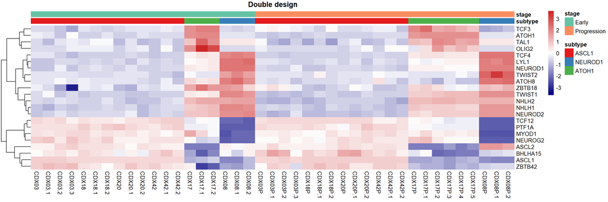

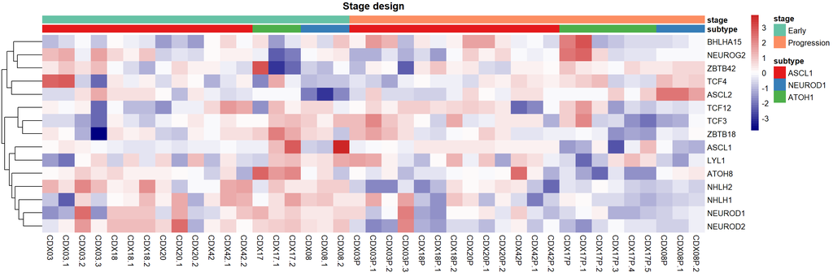

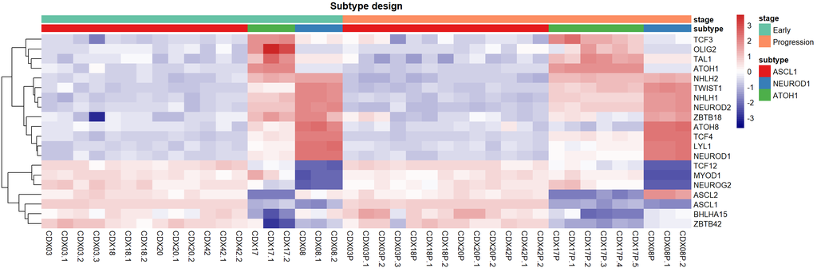

#### GABPA.H14CORE.0.PSM.A

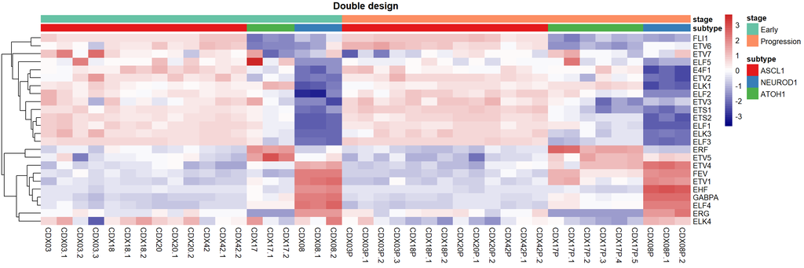

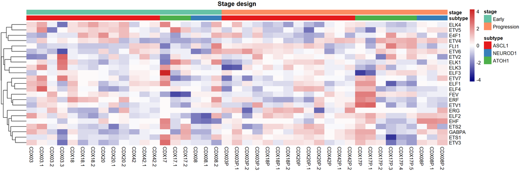

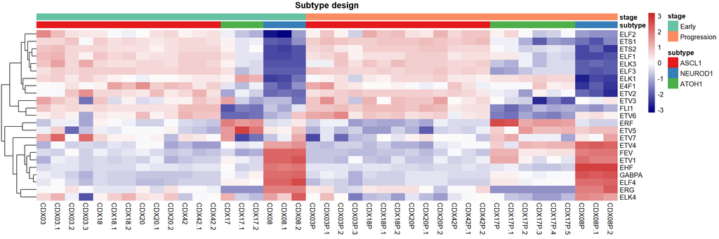

#### E2F1.H14CORE.0.P.B

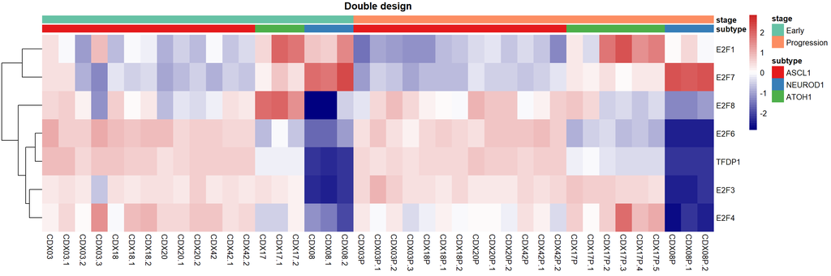

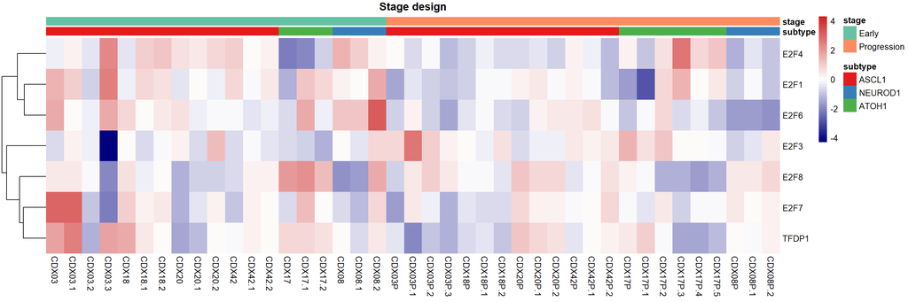

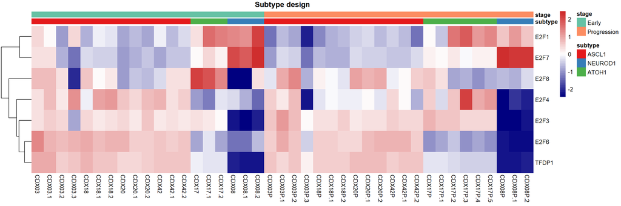

#### RFX4.H14CORE.0.SM.B

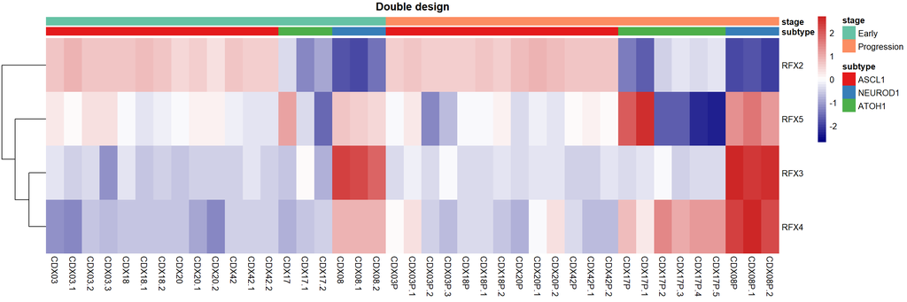

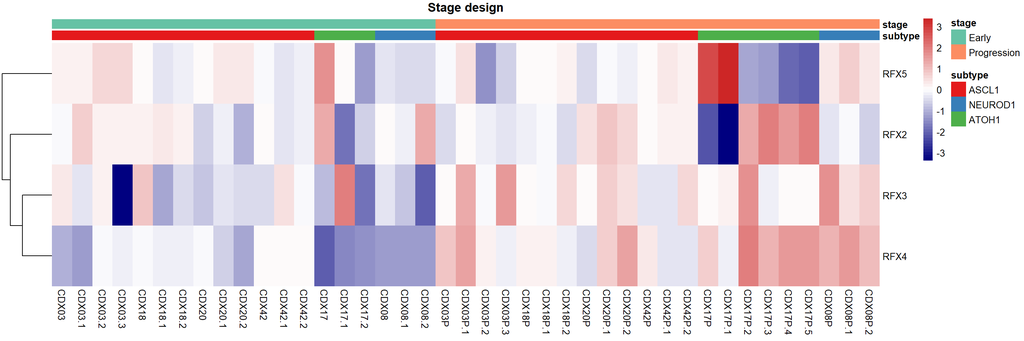

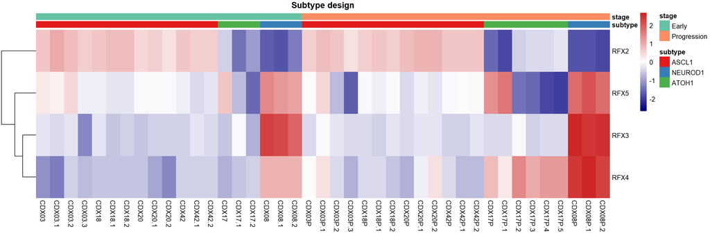

#### IRF9.H14CORE.0.PSM.A

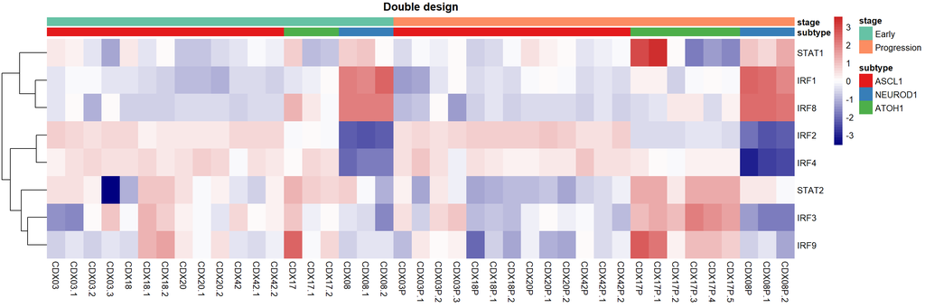

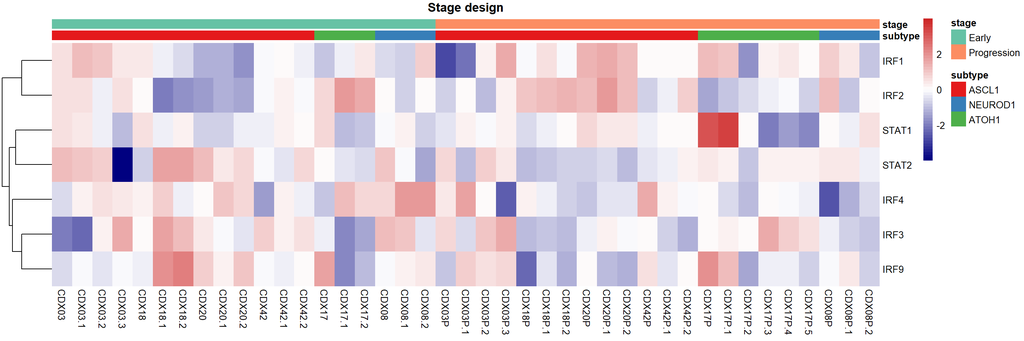

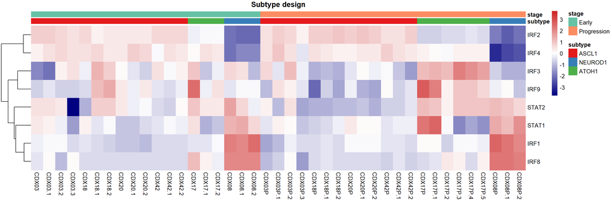

#### NRF1.H14CORE.0.PS.A

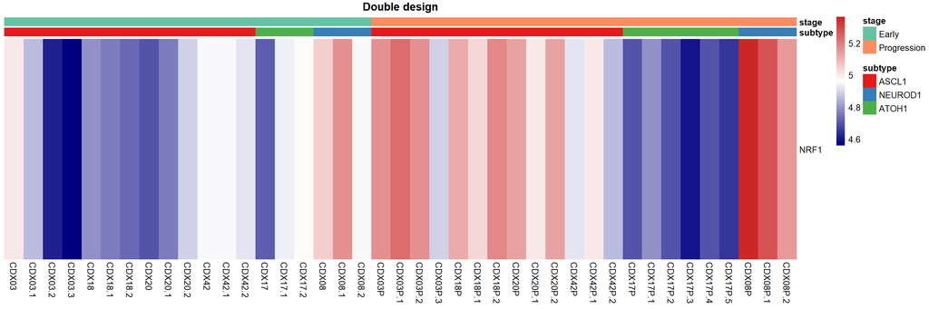

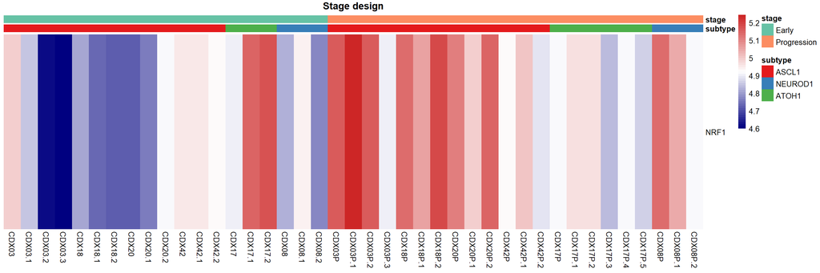

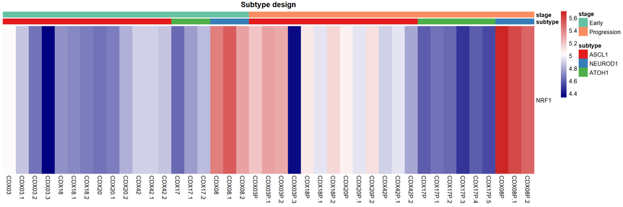

#### REST.H14CORE.0.P.B

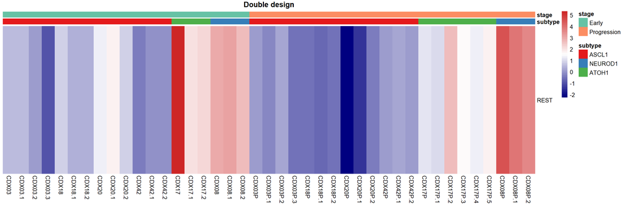

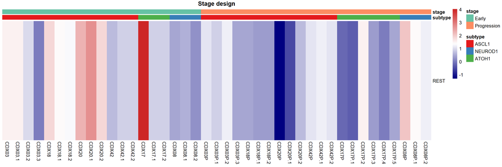

#### HIC1.H14CORE.0.PSM.A

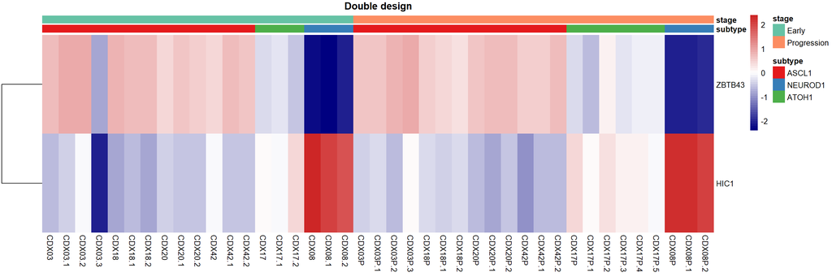

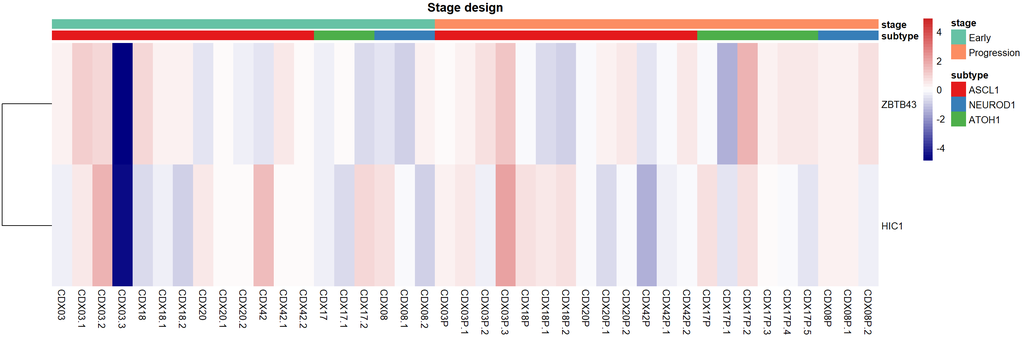

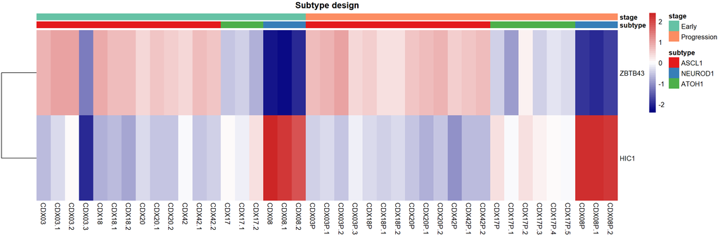